# WHISKEY - Unsupervised Learning Analysis

Tubagus Fathul Arifin

2022-10-21

[figure not shown]

# **1. DATA INTRODUCTION**

As data scientists of a whiskey shop are asked to make a product recommendation for whiskey based on each customer’s taste preferences!

Purpose: to form a group of whiskeys that have a distinctive taste characteristic in each cluster

## **1.1. Data Preparation**

Read the data.

```r
(whiskey <- read.csv("whiskies.txt"))
```

| RowID | Distillery | Body | Sweetness | Smoky | Medicinal | Tobacco | Honey | Spicy | Winey | Nutty | Malty | Fruity | Floral | Postcode | Latitude | Longitude |
| --- | --- | --- | --- | --- | --- | --- | --- | --- | --- | --- | --- | --- | --- | --- | --- | --- |
| 1 | Aberfeldy | 2 | 2 | 2 | 0 | 0 | 2 | 1 | 2 | 2 | 2 | 2 | 2 | \tPH15 2EB | 286580 | 749680 |
| 2 | Aberlour | 3 | 3 | 1 | 0 | 0 | 4 | 3 | 2 | 2 | 3 | 3 | 2 | \tAB38 9PJ | 326340 | 842570 |
| 3 | AnCnoc | 1 | 3 | 2 | 0 | 0 | 2 | 0 | 0 | 2 | 2 | 3 | 2 | \tAB5 5LI | 352960 | 839320 |
| 4 | Ardbeg | 4 | 1 | 4 | 4 | 0 | 0 | 2 | 0 | 1 | 2 | 1 | 0 | \tPA42 7EB | 141560 | 646220 |
| 5 | Ardmore | 2 | 2 | 2 | 0 | 0 | 1 | 1 | 1 | 2 | 3 | 1 | 1 | \tAB54 4NH | 355350 | 829140 |
| 6 | ArranIsleOf | 2 | 3 | 1 | 1 | 0 | 1 | 1 | 1 | 0 | 1 | 1 | 2 | KA27 8HJ | 194050 | 649950 |
| 7 | Auchentoshan | 0 | 2 | 0 | 0 | 0 | 1 | 1 | 0 | 2 | 2 | 3 | 3 | G81 4SJ | 247670 | 672610 |
| 8 | Auchroisk | 2 | 3 | 1 | 0 | 0 | 2 | 1 | 2 | 2 | 2 | 2 | 1 | \tAB55 3XS | 340754 | 848623 |
| 9 | Aultmore | 2 | 2 | 1 | 0 | 0 | 1 | 0 | 0 | 2 | 2 | 2 | 2 | \tAB55 3QY | 340754 | 848623 |
| 10 | Balblair | 2 | 3 | 2 | 1 | 0 | 0 | 2 | 0 | 2 | 1 | 2 | 1 | \tIV19 1LB | 270820 | 885770 |

[output cut: 76 more lines]

```r
glimpse(whiskey)
```

```
## Rows: 86
## Columns: 17
## $ RowID      <int> 1, 2, 3, 4, 5, 6, 7, 8, 9, 10, 11, 12, 13, 14, 15, 16, 17, …
## $ Distillery <chr> "Aberfeldy", "Aberlour", "AnCnoc", "Ardbeg", "Ardmore", "Ar…
## $ Body       <int> 2, 3, 1, 4, 2, 2, 0, 2, 2, 2, 4, 3, 4, 2, 3, 2, 1, 2, 2, 1,…
## $ Sweetness  <int> 2, 3, 3, 1, 2, 3, 2, 3, 2, 3, 3, 2, 2, 2, 2, 2, 2, 2, 2, 1,…
## $ Smoky      <int> 2, 1, 2, 4, 2, 1, 0, 1, 1, 2, 2, 1, 2, 1, 2, 2, 1, 2, 3, 2,…
## $ Medicinal  <int> 0, 0, 0, 4, 0, 1, 0, 0, 0, 1, 0, 0, 0, 0, 0, 0, 0, 0, 1, 2,…
## $ Tobacco    <int> 0, 0, 0, 0, 0, 0, 0, 0, 0, 0, 0, 0, 0, 0, 0, 0, 0, 0, 0, 0,…
## $ Honey      <int> 2, 4, 2, 0, 1, 1, 1, 2, 1, 0, 2, 3, 2, 2, 3, 2, 0, 1, 2, 2,…
## $ Spicy      <int> 1, 3, 0, 2, 1, 1, 1, 1, 0, 2, 1, 2, 2, 2, 1, 2, 1, 2, 2, 2,…
## $ Winey      <int> 2, 2, 0, 0, 1, 1, 0, 2, 0, 0, 3, 1, 0, 0, 1, 1, 1, 2, 1, 1,…
## $ Nutty      <int> 2, 2, 2, 1, 2, 0, 2, 2, 2, 2, 3, 0, 2, 0, 2, 2, 0, 2, 1, 2,…
## $ Malty      <int> 2, 3, 2, 2, 3, 1, 2, 2, 2, 1, 0, 2, 2, 2, 3, 2, 2, 2, 1, 2,…
## $ Fruity     <int> 2, 3, 3, 1, 1, 1, 3, 2, 2, 2, 1, 2, 2, 3, 2, 2, 2, 2, 1, 2,…
## $ Floral     <int> 2, 2, 2, 0, 1, 2, 3, 1, 2, 1, 2, 2, 2, 2, 2, 2, 3, 2, 2, 2,…
## $ Postcode   <chr> " \tPH15 2EB", " \tAB38 9PJ", " \tAB5 5LI", " \tPA42 7EB", …
## $ Latitude   <int> 286580, 326340, 352960, 141560, 355350, 194050, 247670, 340…
## $ Longitude  <dbl> 749680, 842570, 839320, 646220, 829140, 649950, 672610, 848…
```

The data used are Malt Whiskey distillation data from 86 distilleries, obtained from the research of Dr. Wisehart (University of St. Andrews). Each whiskey is scored 0-4 out of 12 flavor categories based on organoleptic tests:  
- `Body`: level of strength of taste (light/heavy)  
- `Sweetness`: level of sweetness  
- `Smoky`: level of smoke taste  
- `Medicinal`: level of bitter taste (medicine)  
- `Tobacco`: tobacco taste level  
- `Honey`: level of honey taste  
- `Spicy`: spicy level  
- `Winey`: wine taste level  
- `Nutty`: nutty flavor level  
- `Malty`: wheat flavor level  
- `Fruity`: fruit flavor level  
- `Floral`: floral flavor level

## **1.2. Data Preprocessing**

Check missing value

```r
anyNA(whiskey)
```

```
## [1] FALSE
```

Data Cleansing

```r
# assign value from Distillery column to row name
rownames(whiskey) <- whiskey$Distillery

# discard unused columns
whiskey <- whiskey %>%
  select(-c(RowID, Distillery, Postcode, Latitude, Longitude))

head(whiskey)
```

|  | Body | Sweetness | Smoky | Medicinal | Tobacco | Honey | Spicy | Winey | Nutty | Malty | Fruity | Floral |
| --- | --- | --- | --- | --- | --- | --- | --- | --- | --- | --- | --- | --- |
| Aberfeldy | 2 | 2 | 2 | 0 | 0 | 2 | 1 | 2 | 2 | 2 | 2 | 2 |
| Aberlour | 3 | 3 | 1 | 0 | 0 | 4 | 3 | 2 | 2 | 3 | 3 | 2 |
| AnCnoc | 1 | 3 | 2 | 0 | 0 | 2 | 0 | 0 | 2 | 2 | 3 | 2 |
| Ardbeg | 4 | 1 | 4 | 4 | 0 | 0 | 2 | 0 | 1 | 2 | 1 | 0 |
| Ardmore | 2 | 2 | 2 | 0 | 0 | 1 | 1 | 1 | 2 | 3 | 1 | 1 |
| ArranIsleOf | 2 | 3 | 1 | 1 | 0 | 1 | 1 | 1 | 0 | 1 | 1 | 2 |

# **2. DATA EXPLORATORY**

Check the scale between variables

```r
summary(whiskey)
```

```
##       Body        Sweetness         Smoky         Medicinal
##  Min.   :0.00   Min.   :1.000   Min.   :0.000   Min.   :0.0000
##  1st Qu.:2.00   1st Qu.:2.000   1st Qu.:1.000   1st Qu.:0.0000
##  Median :2.00   Median :2.000   Median :1.000   Median :0.0000
##  Mean   :2.07   Mean   :2.291   Mean   :1.535   Mean   :0.5465
##  3rd Qu.:2.00   3rd Qu.:3.000   3rd Qu.:2.000   3rd Qu.:1.0000
##  Max.   :4.00   Max.   :4.000   Max.   :4.000   Max.   :4.0000
##     Tobacco           Honey           Spicy           Winey
##  Min.   :0.0000   Min.   :0.000   Min.   :0.000   Min.   :0.0000
##  1st Qu.:0.0000   1st Qu.:1.000   1st Qu.:1.000   1st Qu.:0.0000
##  Median :0.0000   Median :1.000   Median :1.000   Median :1.0000
##  Mean   :0.1163   Mean   :1.244   Mean   :1.384   Mean   :0.9767
##  3rd Qu.:0.0000   3rd Qu.:2.000   3rd Qu.:2.000   3rd Qu.:1.0000
##  Max.   :1.0000   Max.   :4.000   Max.   :3.000   Max.   :4.0000
##      Nutty           Malty           Fruity          Floral
##  Min.   :0.000   Min.   :0.000   Min.   :0.000   Min.   :0.000
##  1st Qu.:1.000   1st Qu.:1.000   1st Qu.:1.000   1st Qu.:1.000
##  Median :2.000   Median :2.000   Median :2.000   Median :2.000
##  Mean   :1.465   Mean   :1.802   Mean   :1.802   Mean   :1.698
##  3rd Qu.:2.000   3rd Qu.:2.000   3rd Qu.:2.000   3rd Qu.:2.000
##  Max.   :4.000   Max.   :3.000   Max.   :3.000   Max.   :4.000
```

since the data types are quite the same, so there is no need to do scaling.

Here we will explore the data distribution of each numeric variable using density plot and the correlation between each variable using scatterplot which were provided within `ggpairs` function from GGally package.

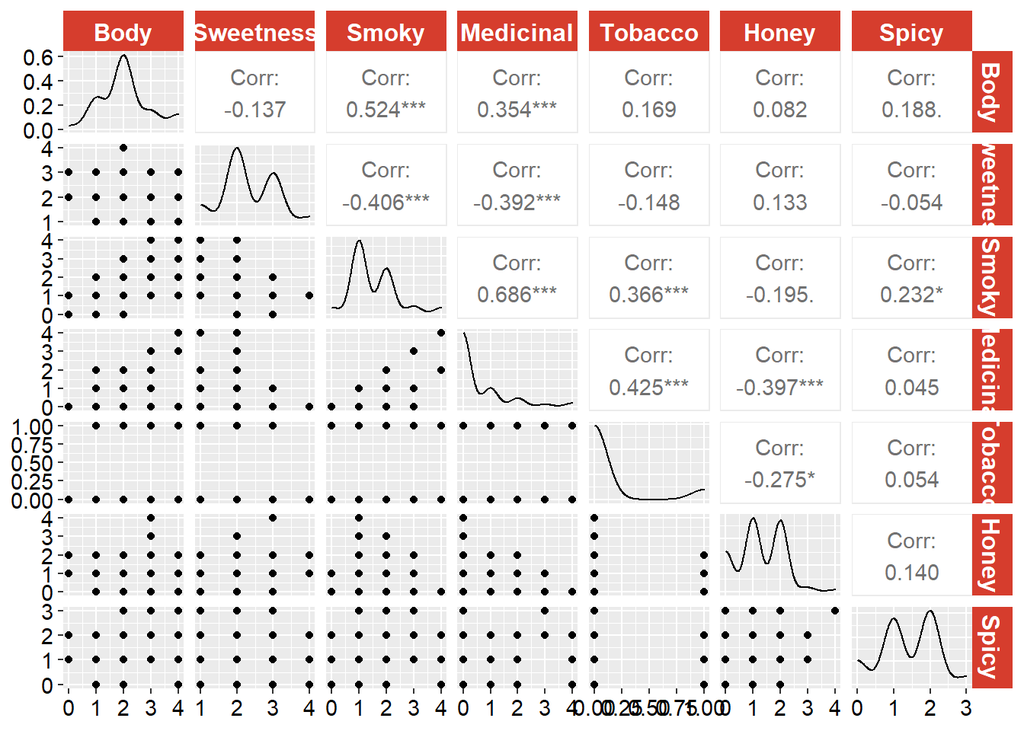

```r
ggpairs(whiskey[,c(1:7)], showStrips = F) +
  theme(axis.text = element_text(colour = "black", size = 11),
        strip.background = element_rect(fill = "#d63d2d"),
        strip.text = element_text(colour = "white", size = 12,
                                  face = "bold"))
```

It can be seen that there is a strong correlation between some variables from the data, including `Body`-`Smoky`, `Smoky`-`Medicinal.` This result indicates that this dataset has multicollinearity and might not be suitable for various classification algorithms (which have non-multicollinearity as their assumption).

**Principal Component Analysis** can be performed for this data to produce non-multicollinearity data, while also reducing the dimension of the data and retaining as much as information possible. The result of this analysis can be utilized further for classification purpose with lower computation.